# GxA results version 1

Andrey Ziyatdinov

2017-09-19

# 1 Previos versions

- [GxA results version 1 @ 2017-09-19](https://hemostat.github.io/Public/copdgene/results/02-scan-ver-1/02-scan-ver-1.html)
- [Current version (this document)](https://hemostat.github.io/Public/copdgene/results/02-scan-ver-1/02-scan-ver-1.html)

# 2 Description of results

## 2.1 Significannt thresholds

### 2.1.1 Bonferroni threshold

```r
0.05 / 37e3
```

```
[1] 1.351351e-06
```

- None of association signals per traits survives the multiple-testing correction.
- The Bonferroni threshold is conservative for our (corelated) tests.

# 3 Models version 1

| trait | ver | formula |
| --- | --- | --- |
| FEV1_FVC_utah | 9 | FEV1_FVC_utah ~ Age_Enroll + Age_Enroll2 + gender + Duration_Smoking + log_CigPerDaySmokAvg + SmokCigNow + SmokCigNow0_15 + acs_global + (0 + dummy(SmokCigNow0_15Rev)\|rsid1) + (0 + dummy(SmokCigNowRe… |
| FEV1pp_utah | 9 | FEV1pp_utah ~ Age_Enroll + gender + Duration_Smoking + log_CigPerDaySmokAvg + SmokCigarNow + SmokCigNow + SmokCigNow0_15 + acs_global + (0 + dummy(SmokCigNow0_15Rev)\|rsid1) + (0 + dummy(SmokCigNowRev… |
| FEV1_utah | 9 | FEV1_utah ~ Age_Enroll + Age_Enroll2 + gender + Height_CM + Duration_Smoking + log_CigPerDaySmokAvg + SmokCigarNow + SmokCigNow + SmokCigNow0_15 + acs_global + (0 + dummy(SmokCigNow0_15Rev)\|rsid1) + … |
| FVCpp_utah | 9 | FVCpp_utah ~ Age_Enroll + gender + Duration_Smoking + log_CigPerDaySmokAvg + SmokCigarNow + SmokCigNow + SmokCigNow0_15 + acs_global + (0 + dummy(SmokCigNow0_15Rev)\|rsid1) + (0 + dummy(SmokCigNowRev)… |
| FVC_utah | 9 | FVC_utah ~ Age_Enroll + Age_Enroll2 + gender + Height_CM + Duration_Smoking + log_CigPerDaySmokAvg + SmokCigarNow + SmokCigNow + SmokCigNow0_15 + acs_global + (0 + dummy(SmokCigNow0_15Rev)\|rsid1) + (… |
| log_pctEmph_Slicer | 9 | log_pctEmph_Slicer ~ Age_Enroll + gender + Duration_Smoking + log_CigPerDaySmokAvg + SmokCigarNow + SmokCigNow + SmokCigNow0_15 + acs_global + (0 + dummy(SmokCigNow0_15Rev)\|rsid1) + (0 + dummy(SmokCi… |
| TLCpp_race_adjusted | 9 | TLCpp_race_adjusted ~ Age_Enroll + gender + Duration_Smoking + log_CigPerDaySmokAvg + SmokCigarNow + SmokCigNow + SmokCigNow0_15 + acs_global + (0 + dummy(SmokCigNow0_15Rev)\|rsid1) + (0 + dummy(SmokC… |

# 4 Single-trait association

- Figure: qq-plot of p-values coming from linear mixed model
- Table of the top signals was produced as follows:
  1. filter out associations with p-values above 0.001
  2. join results across traits
  3. filter top results
     - create a summary table with the lowest p-value across traits
     - take only top 5 associations from each chromosome
     - recored acs. segments remained
  4. filter top results by those acs. segments remained
  5. note that some p-values can be lost, but the highest p-values per each chromosome are shown
- Gene annotation is performed withing 100,000b window.

## 4.1 `SmokCigNow`

### 4.1.1 QQ plots

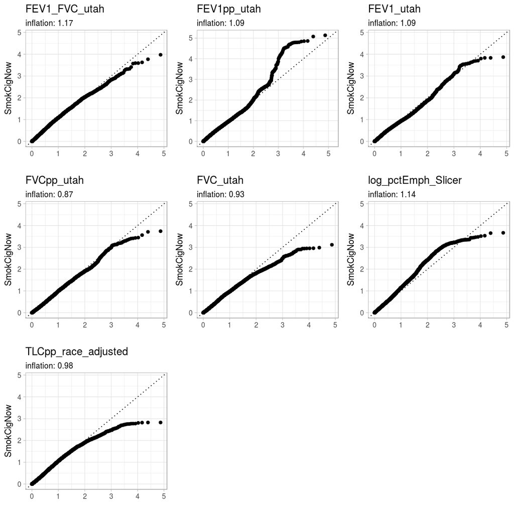

### 4.1.2 Manhattan plots

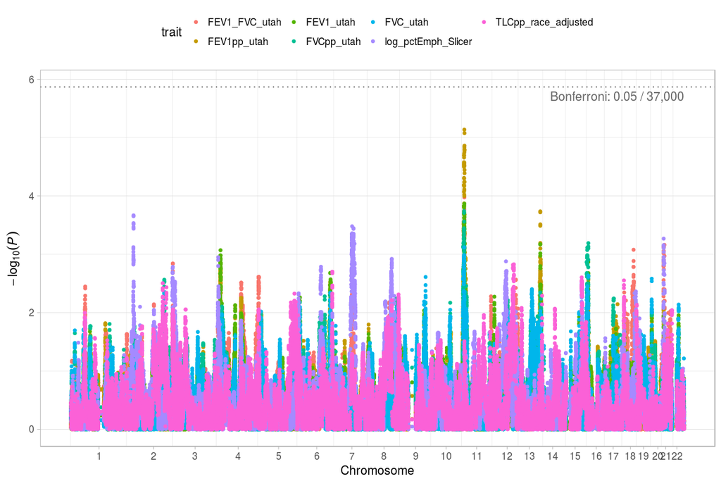

Chr 11, near *PARVA* gene

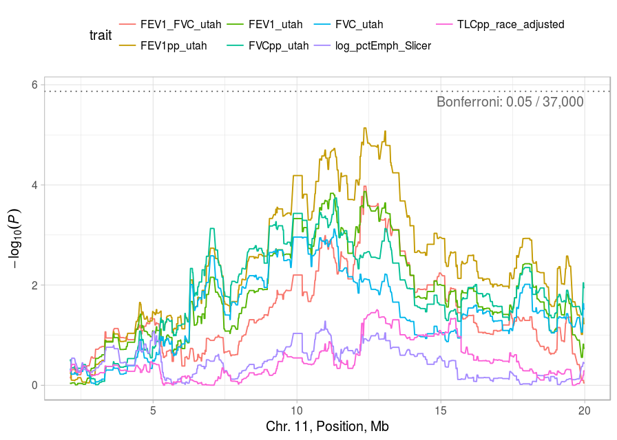

Chr 13:

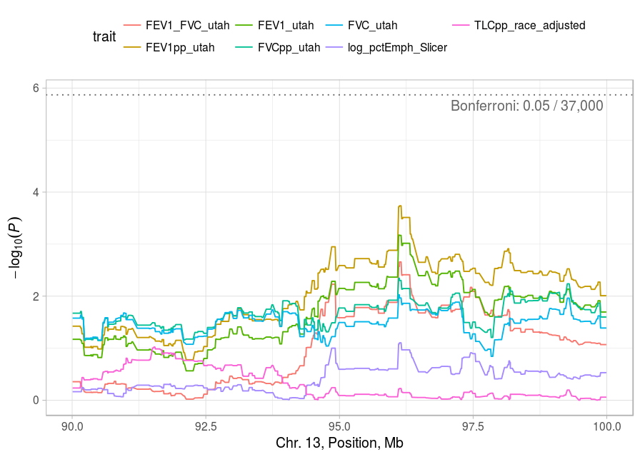

### 4.1.3 Table of (pruned) top signals

| acs | chr | pos_start | pos_end | zscore | p_value | trait | genes |
| --- | --- | --- | --- | --- | --- | --- | --- |
| chr11acs94182 | 11 | 12,332,105 | 12,394,102 | 4.5 | 7.3e-06 | FEV1pp_utah | MICAL2, , MICALCL, , PARVA |
|  | 11 | 12,332,105 | 12,394,102 | 3.9 | 1.1e-04 | FEV1_FVC_utah |  |
|  | 11 | 12,332,105 | 12,394,102 | 3.8 | 1.4e-04 | FEV1_utah |  |
| chr11acs94256 | 11 | 13,059,052 | 13,077,526 | 4.5 | 8.4e-06 | FEV1pp_utah | LINC00958, , RASSF10, , |
|  | 11 | 13,059,052 | 13,077,526 | 3.7 | 2.3e-04 | FEV1_utah |  |
|  | 11 | 13,059,052 | 13,077,526 | 3.5 | 4.7e-04 | FEV1_FVC_utah |  |
|  | 11 | 13,059,052 | 13,077,526 | 3.4 | 7.4e-04 | FVCpp_utah |  |
| chr11acs94248 | 11 | 12,958,762 | 13,031,246 | 4.3 | 1.4e-05 | FEV1pp_utah | TEAD1, , , LINC00958, , RASSF10, |
|  | 11 | 12,958,762 | 13,031,246 | 3.6 | 2.9e-04 | FEV1_utah |  |
|  | 11 | 12,958,762 | 13,031,246 | 3.5 | 5.0e-04 | FEV1_FVC_utah |  |
| chr11acs94173 | 11 | 12,249,837 | 12,294,098 | 4.3 | 1.4e-05 | FEV1pp_utah | MICAL2, MIR6124, , MICALCL, , PARVA |
|  | 11 | 12,249,837 | 12,294,098 | 3.8 | 1.7e-04 | FEV1_FVC_utah |  |
|  | 11 | 12,249,837 | 12,294,098 | 3.7 | 2.6e-04 | FEV1_utah |  |
| chr11acs94197 | 11 | 12,461,900 | 12,511,209 | 4.3 | 1.5e-05 | FEV1pp_utah | PARVA, |
|  | 11 | 12,461,900 | 12,511,209 | 3.7 | 2.6e-04 | FEV1_FVC_utah |  |
|  | 11 | 12,461,900 | 12,511,209 | 3.7 | 2.6e-04 | FEV1_utah |  |
| chr13acs112682 | 13 | 96,121,934 | 96,152,245 | -3.7 | 1.8e-04 | FEV1pp_utah | UGGT2, HS6ST3, RN7SL164P |
|  | 13 | 96,121,934 | 96,152,245 | -3.4 | 6.8e-04 | FEV1_utah |  |
| chr13acs112681 | 13 | 96,106,588 | 96,120,203 | -3.7 | 1.9e-04 | FEV1pp_utah | UGGT2, HS6ST3, RN7SL164P |
|  | 13 | 96,106,588 | 96,120,203 | -3.4 | 6.7e-04 | FEV1_utah |  |
| chr2acs12992 | 2 | 30,914,896 | 30,931,500 | -3.7 | 2.1e-04 | log_pctEmph_Slicer | CAPN13, GALNT14, |
| chr2acs12991 | 2 | 30,890,989 | 30,902,121 | -3.7 | 2.2e-04 | log_pctEmph_Slicer | CAPN13, GALNT14, |
| chr2acs12990 | 2 | 30,854,147 | 30,887,761 | -3.6 | 2.9e-04 | log_pctEmph_Slicer | CAPN13, GALNT14, |
| chr2acs12999 | 2 | 30,976,102 | 31,000,001 | -3.6 | 3.1e-04 | log_pctEmph_Slicer | GALNT14, |
| chr13acs112684 | 13 | 96,184,073 | 96,313,752 | -3.6 | 3.1e-04 | FEV1pp_utah | HS6ST3, RN7SL164P |
|  | 13 | 96,184,073 | 96,313,752 | -3.3 | 9.6e-04 | FEV1_utah |  |
| chr13acs112683 | 13 | 96,164,160 | 96,180,371 | -3.6 | 3.2e-04 | FEV1pp_utah | HS6ST3, RN7SL164P |
| chr7acs65555 | 7 | 80,448,505 | 80,459,519 | 3.6 | 3.3e-04 | log_pctEmph_Slicer | , CD36, SNRPBP1, GNAT3 |
| chr2acs12979 | 2 | 30,799,400 | 30,820,191 | -3.6 | 3.4e-04 | log_pctEmph_Slicer | CAPN13, , GALNT14 |
| chr7acs65822 | 7 | 86,308,665 | 86,320,624 | 3.6 | 3.6e-04 | log_pctEmph_Slicer | SOCS5P1 |
| chr7acs65823 | 7 | 86,340,669 | 86,386,947 | 3.6 | 3.7e-04 | log_pctEmph_Slicer |  |
| chr7acs65565 | 7 | 80,541,893 | 80,556,294 | 3.5 | 4.4e-04 | log_pctEmph_Slicer | CD36, GNAT3 |
| chr7acs65819 | 7 | 86,211,311 | 86,297,283 | 3.5 | 4.4e-04 | log_pctEmph_Slicer | SOCS5P1 |
| chr20acs147875 | 20 | 56,488,558 | 56,551,021 | 3.5 | 5.4e-04 | log_pctEmph_Slicer | AURKA, CSTF1, CASS4, , RTFDC1, GCNT7, FAM209A, , FAM209B, LINC01716, RPS4XP3, TFAP2C |
| chr13acs112687 | 13 | 96,324,226 | 96,336,985 | -3.4 | 6.4e-04 | FEV1pp_utah | HS6ST3, MIR4501 |
| chr15acs124856 | 15 | 98,653,979 | 98,675,178 | -3.4 | 6.4e-04 | FVCpp_utah | , IGF1R, |
| chr20acs148288 | 20 | 59,772,085 | 59,788,426 | -3.4 | 6.9e-04 | FEV1_FVC_utah | PHACTR3, RNU7-141P, SYCP2 |
| chr20acs147865 | 20 | 56,429,346 | 56,447,279 | 3.4 | 7.0e-04 | log_pctEmph_Slicer | FAM210B, AURKA, CSTF1, CASS4, , RTFDC1, GCNT7, FAM209A, , FAM209B |
| chr20acs147863 | 20 | 56,417,500 | 56,427,895 | 3.4 | 7.2e-04 | log_pctEmph_Slicer | FAM210B, AURKA, CSTF1, CASS4, , RTFDC1, GCNT7, FAM209A, |
|  | 20 | 56,417,500 | 56,427,895 | -3.3 | 9.6e-04 | FEV1_FVC_utah |  |
| chr15acs124864 | 15 | 98,694,565 | 98,708,276 | -3.4 | 7.4e-04 | FVCpp_utah | , IGF1R, , MIR4714 |
| chr20acs147897 | 20 | 56,613,415 | 56,640,019 | -3.4 | 7.4e-04 | FEV1_FVC_utah | RTFDC1, GCNT7, FAM209A, , FAM209B, LINC01716, RPS4XP3, TFAP2C, RNU6-1146P, RN7SL170P, PTMAP6, |
|  | 20 | 56,613,415 | 56,640,019 | 3.4 | 7.9e-04 | log_pctEmph_Slicer |  |
| chr15acs124393 | 15 | 93,980,394 | 94,008,761 | -3.4 | 7.7e-04 | FVCpp_utah | LINC01579, , LINC01580, LINC01581, |
| chr15acs124867 | 15 | 98,736,980 | 98,832,747 | -3.4 | 7.9e-04 | FVCpp_utah | , IGF1R, , MIR4714, |
| chr18acs138442 | 18 | 51,728,344 | 51,827,201 | 3.3 | 8.4e-04 | FEV1_FVC_utah | LINC01630, , |
| chr15acs124363 | 15 | 93,740,655 | 93,803,636 | -3.3 | 8.4e-04 | FVCpp_utah | , LINC01579, , , LINC02207, , LINC01580 |
| chr4acs35359 | 4 | 18,567,173 | 18,615,086 | 3.3 | 8.5e-04 | FEV1_utah |  |

## 4.2 `SmokCigNow0_15`

### 4.2.1 QQ plots

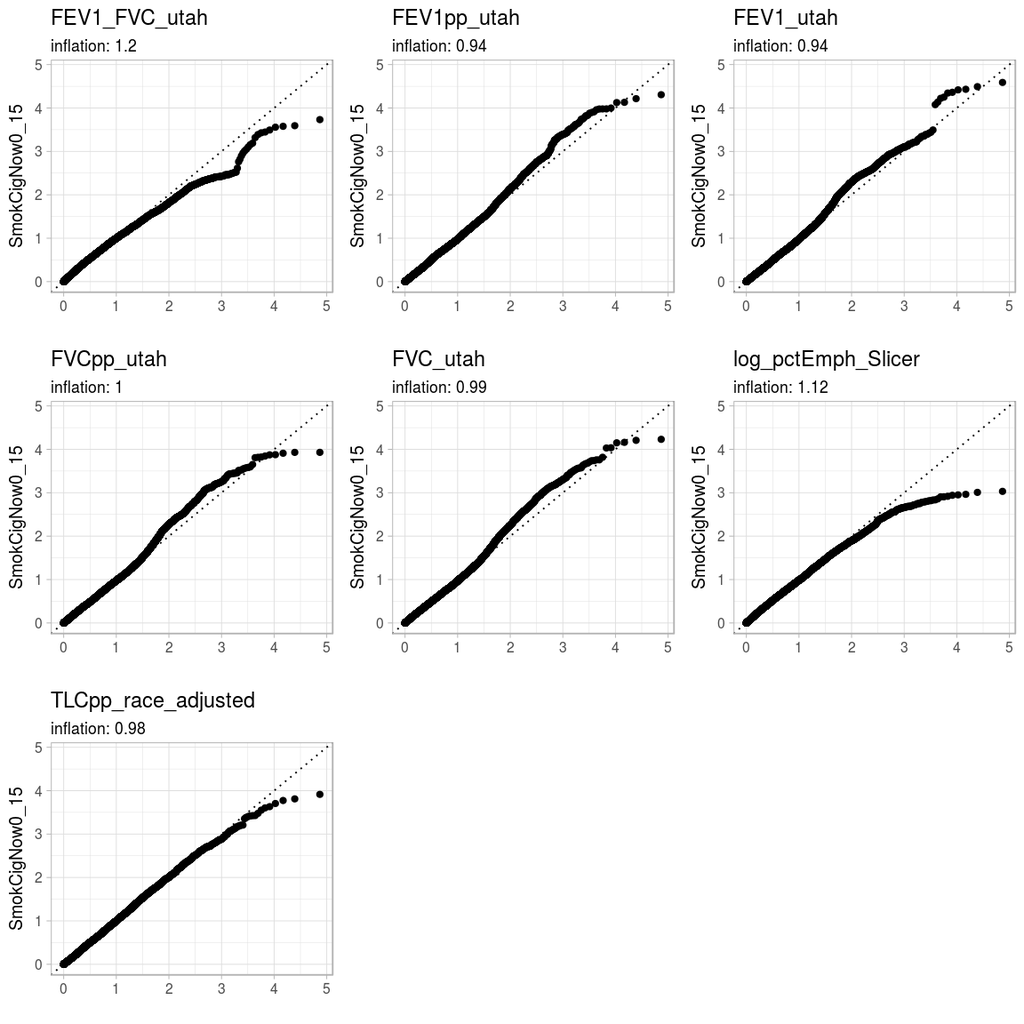

### 4.2.2 Manhattan plots

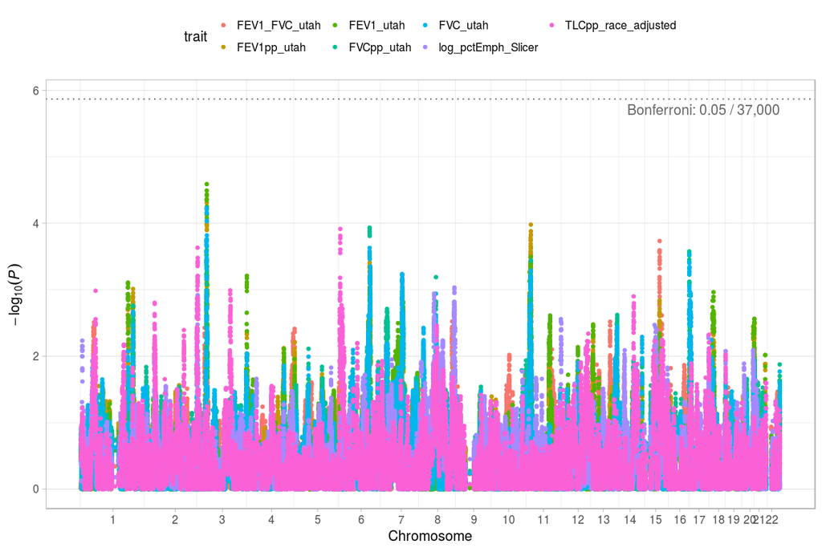

Chr 2, near *TWIST2* gene:

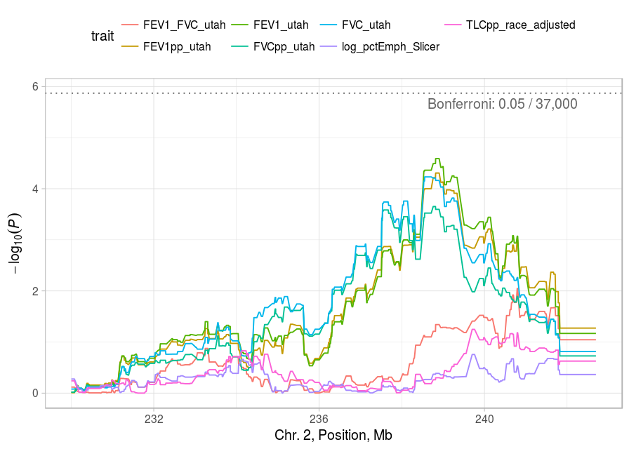

### 4.2.3 Table of (pruned) top signals

| acs | chr | pos_start | pos_end | zscore | p_value | trait | genes |
| --- | --- | --- | --- | --- | --- | --- | --- |
| chr2acs23410 | 2 | 238,819,792 | 238,904,351 | 4.2 | 2.6e-05 | FEV1_utah | LINC01937, , , TWIST2, LINC01940 |
|  | 2 | 238,819,792 | 238,904,351 | 4.1 | 4.9e-05 | FEV1pp_utah |  |
|  | 2 | 238,819,792 | 238,904,351 | 4.0 | 6.9e-05 | FVC_utah |  |
|  | 2 | 238,819,792 | 238,904,351 | 3.7 | 2.5e-04 | FVCpp_utah |  |
| chr2acs23409 | 2 | 238,760,161 | 238,815,554 | 4.2 | 3.2e-05 | FEV1_utah | LINC01937, , , TWIST2 |
|  | 2 | 238,760,161 | 238,815,554 | 4.0 | 6.1e-05 | FEV1pp_utah |  |
|  | 2 | 238,760,161 | 238,815,554 | 4.0 | 6.2e-05 | FVC_utah |  |
|  | 2 | 238,760,161 | 238,815,554 | 3.7 | 2.2e-04 | FVCpp_utah |  |
| chr2acs23414 | 2 | 238,983,019 | 239,001,231 | 4.1 | 3.7e-05 | FEV1_utah | TWIST2, LINC01940, HDAC4, MIR4440, MIR4441 |
|  | 2 | 238,983,019 | 239,001,231 | 4.0 | 7.4e-05 | FEV1pp_utah |  |
|  | 2 | 238,983,019 | 239,001,231 | 3.9 | 9.2e-05 | FVC_utah |  |
|  | 2 | 238,983,019 | 239,001,231 | 3.6 | 3.6e-04 | FVCpp_utah |  |
| chr2acs23413 | 2 | 238,944,123 | 238,982,802 | 4.1 | 3.8e-05 | FEV1_utah | TWIST2, LINC01940, HDAC4, MIR4440 |
|  | 2 | 238,944,123 | 238,982,802 | 4.0 | 7.5e-05 | FEV1pp_utah |  |
|  | 2 | 238,944,123 | 238,982,802 | 3.9 | 9.3e-05 | FVC_utah |  |
|  | 2 | 238,944,123 | 238,982,802 | 3.6 | 3.6e-04 | FVCpp_utah |  |
| chr2acs23401 | 2 | 238,553,713 | 238,712,649 | 4.1 | 4.3e-05 | FEV1_utah | , LINC01107, LINC01937, , |
|  | 2 | 238,553,713 | 238,712,649 | 4.0 | 5.9e-05 | FVC_utah |  |
|  | 2 | 238,553,713 | 238,712,649 | 3.9 | 1.0e-04 | FEV1pp_utah |  |
|  | 2 | 238,553,713 | 238,712,649 | 3.6 | 3.0e-04 | FVCpp_utah |  |
| chr11acs94504 | 11 | 17,853,990 | 17,880,252 | 3.9 | 1.0e-04 | FEV1pp_utah | KCNC1, SERGEF |
|  | 11 | 17,853,990 | 17,880,252 | 3.6 | 3.2e-04 | FEV1_utah |  |
|  | 11 | 17,853,990 | 17,880,252 | 3.6 | 3.7e-04 | FVCpp_utah |  |
|  | 11 | 17,853,990 | 17,880,252 | 3.5 | 5.3e-04 | FVC_utah |  |
| chr6acs57946 | 6 | 117,898,836 | 117,928,944 | 3.9 | 1.2e-04 | FVCpp_utah | SLC35F1, |
|  | 6 | 117,898,836 | 117,928,944 | 3.7 | 2.4e-04 | FVC_utah |  |
|  | 6 | 117,898,836 | 117,928,944 | 3.5 | 4.7e-04 | FEV1pp_utah |  |
| chr6acs57944 | 6 | 117,749,188 | 117,872,714 | 3.9 | 1.2e-04 | FVCpp_utah | NUS1, SLC35F1 |
|  | 6 | 117,749,188 | 117,872,714 | 3.6 | 2.7e-04 | FVC_utah |  |
|  | 6 | 117,749,188 | 117,872,714 | 3.4 | 6.8e-04 | FEV1pp_utah |  |

[output cut: 59 more lines]

## 4.3 `SchoolCompleted_gr2`

### 4.3.1 QQ plots

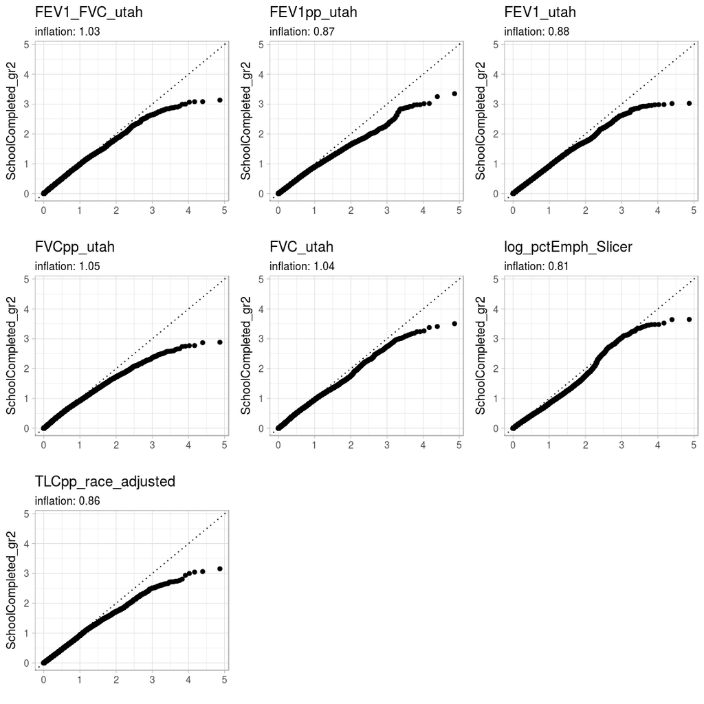

### 4.3.2 Manhattan plots

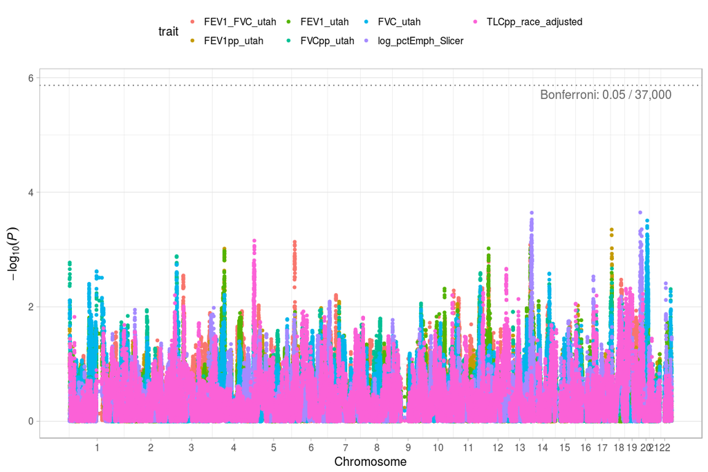

### 4.3.3 Table of (pruned) top signals

[output not shown]

# 5 Multi-trait association (`SmokCigNow`)

## 5.1 `FEV1pp_utah` and `FEV1_utah` are correlated

Chr 11, near *PARVA* gene:

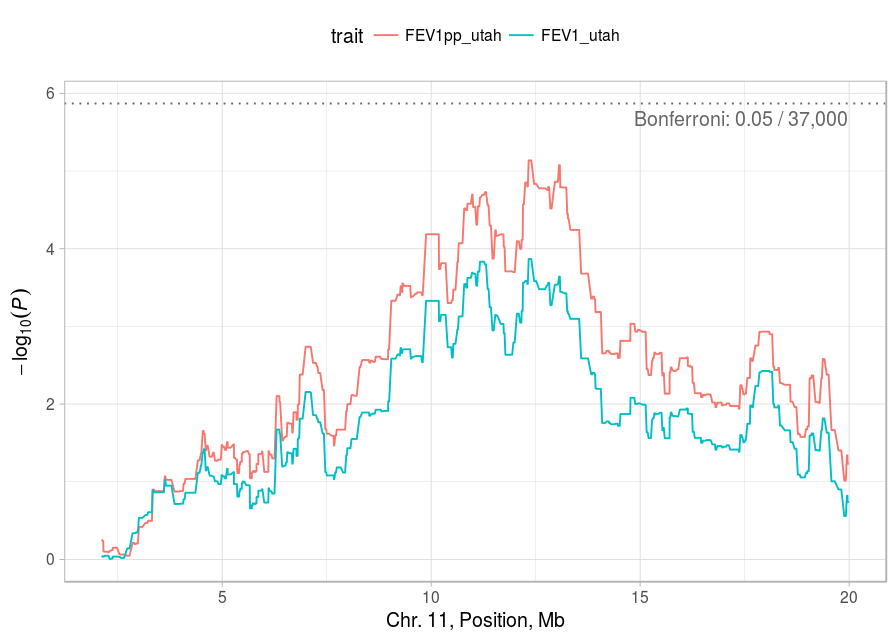

## 5.2 Correlation among z-scores

### 5.2.1 Protocol

1. Standartize `z_i`
2. Filter `z_i` by threshold (default value 2)
3. Run ML optimization (R function `optim`, method `Brent`) for each pairs of `z_i` and `z_j` separately
   - the likelihood is derived for truncated MVN (Hugo’s R code)

### 5.2.2 Comparison of methods

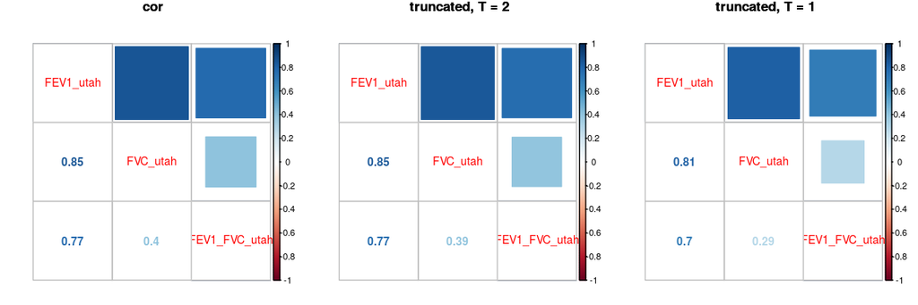

### 5.2.3 Z-score correlations (truncated, T = 2)

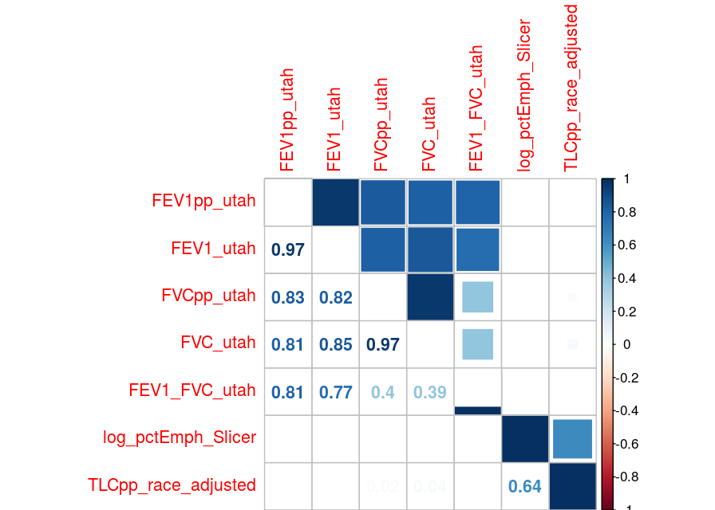

### 5.2.4 Z-score correlations (cor)

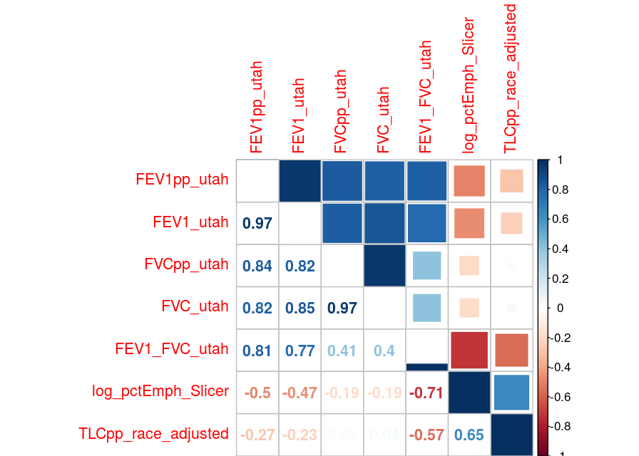

## 5.3 Omnibus test on 7 traits (tuncated, T = 2)

### 5.3.1 Manhattan plot

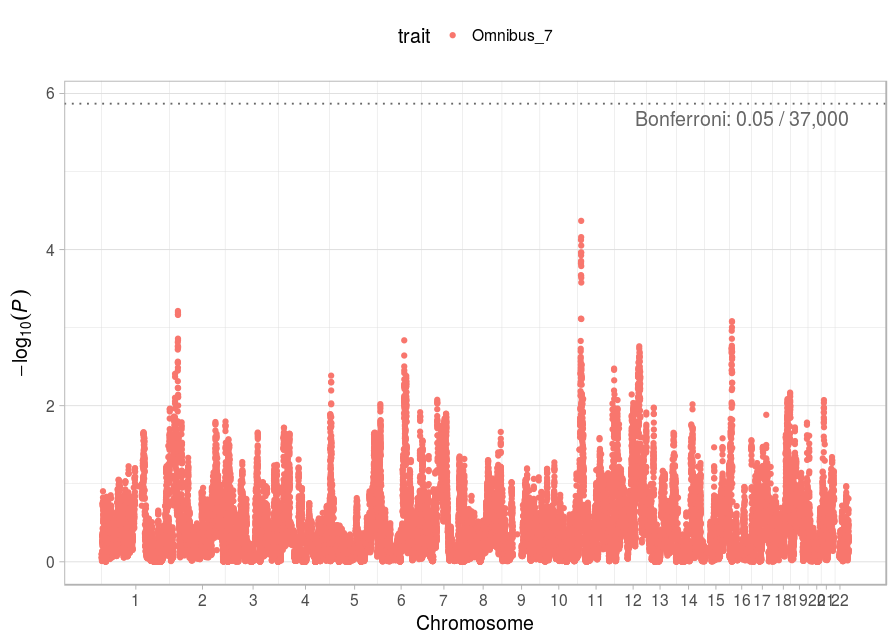

Chr 11, near *PARVA* gene:

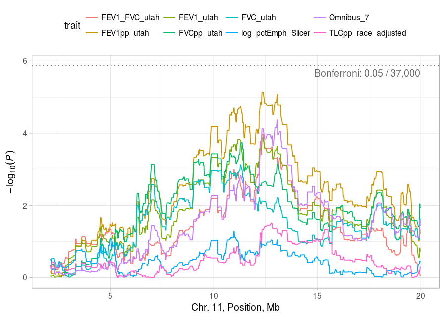